# Project 4: Causal Inference Algorithms Evaluation

Group 8

04/07/2021

## Setup

First, we set working directories as needed, install required libraries and import the data.

## Introduction

In this project, we are looking for the best algorithm for causal inference of propensity scores to see how close the estimated average treatment effects (ATEs) are to the true ATEs. For the estimation of propensity scores, we use regression trees. The algorithms we use to estimate ATEs in this project are propensity matching, stratification and weighted regression. We also compare the run times of different algorithms and propensity score estimations across both data sets.

## About the Data

```
## [1] "High Dimensional Data"
```

```
##
##      0      1
## 0.6785 0.3215
```

```
## [1] "Low Dimensional Data"
```

```
##
##     0     1
## 0.788 0.212
```

## Background

### Regression Trees

The mathematical formula for a regression tree is shown below.

$$\hat{f}(x) = \sum_{m = 1}^{M} c_{m}I\{x \in R_{m}\}$$

Here, $R_m$ is a specific region, $M$ is the number of regions, and $c_m$ is the value associated with a region.

The way regression trees work is that the space is split into multiple regions based on some set of decisions. This process keeps repeating until a stopping rule is applied. In regression, we use **squared error loss** to find the optimal tree model, but in classification, as with the case for estimating propensity scores, we use a measure of impurity. In our case, we use one called the **Gini index**. In R, we use “rpart” library to run the regression tree algorithm. The parameters of the function includes **minsplit**, **minbucket** and **cp**. The parameter of **cp** indicates the complexity of the model, we get more complex trees with lower values of “cp”.

We can visualize the tree and the decision rules at each split, using the **plot.rpart** function in R. The decision rules help to determine which variables are of the highest importance when estimating the propensity scores.

### Propensity Scores

The propensity score is defined as follows:

$$e(x) = Pr(T = 1 | X = x), ~ 0 < e(x) < 1$$

Based on the formula above, given the (multiple) covariates ($x$), the propensity score is the probability that the observation is in the treatment group (in our case, observations where $A = 1$). Since, our data is based on observational studies, we can use propensity scores to make causal inferences.

### Average Treatment Effect (ATE)

The average treatment effect is defined as follows:

$$\Delta_{t} = E(Y_{1} - Y_{0} | T = 1)$$

ATE is defined as the difference in the average outcomes between observations assigned to treatment group and the control group. This allows us to measure the effect a treatment had on each group.

## Cross-Validation

### Step 1: Set Controls and Establish Hyperparameters

We set up the controls to start the the cross validation process

```r
K <- 5  # number of CV folds
sample.reweight <- TRUE # run sample reweighting in model training

# setting the following to false loads data generated from a previous run
# this data is the same in each run due to a set seed

run.cv.trees_high <- TRUE # run cross-validation on the training set for trees on high dim data

run.cv.trees_low <- TRUE # run cross-validation on the training set for trees on low dim data
```

```r
# hyperparameters for trees
hyper_grid_trees <- expand.grid(
  maxdepth = c(1, 5, 10, 15, 20, 25, 30)
)
```

### Step 2: Cross-Validate the Hyperparameters

```r
# data pre-processing

# features are the predictors: V1 - Vp
# column 1 is the response Y
# column 2 is the treatment A

feature_train_high = df_high[, -1:-2]
label_train_high = df_high[, 2]

feature_train_low = df_low[, -1:-2]
label_train_low = df_low[, 2]
```

#### High Dimensional Data

We run the cross validation algorithm on the high dimensional data.

```r
set.seed(5243)

if(run.cv.trees_high){
  res_cv_trees_high <- matrix(0, nrow = nrow(hyper_grid_trees), ncol = 4)
  for(i in 1:nrow(hyper_grid_trees)){
    cat("complexity = ", hyper_grid_trees$cp[i], "\n", sep = "")
    res_cv_trees_high[i,] <- cv.function(features = feature_train_high,
                                         labels = label_train_high,
                                         maxdepth = hyper_grid_trees$maxdepth[i],
                                         K, reweight = sample.reweight)
  save(res_cv_trees_high, file = "../output/res_cv_trees_high.RData")
  }
} else{
  load("../output/res_cv_trees_high.RData")
}
```

```
## complexity =
## complexity =
## complexity =
## complexity =
## complexity =
## complexity =
## complexity =
```

#### Low Dimensional Data

```r
set.seed(5243)

if(run.cv.trees_low){
  res_cv_trees_low <- matrix(0, nrow = nrow(hyper_grid_trees), ncol = 4)
  for(i in 1:nrow(hyper_grid_trees)){
    cat("complexity = ", hyper_grid_trees$cp[i], "\n", sep = "")
    res_cv_trees_low[i,] <- cv.function(features = feature_train_low,
                                        labels = label_train_low,
                                        maxdepth = hyper_grid_trees$maxdepth[i],
                                        K, reweight = sample.reweight)
  save(res_cv_trees_low, file="../output/res_cv_trees_low.RData")
  }
}else{
  load("../output/res_cv_trees_low.RData")
}
```

```
## complexity =
## complexity =
## complexity =
## complexity =
## complexity =
## complexity =
## complexity =
```

### Step 3: Visualize CV Error and AUC

After cross validating, we obtain the mean error and the AUC values for each potential “maxdepth” value for both data sets. We display these values and associated standard errors in the plots below.

Because of the imbalances in the groups for both datasets, we choose to not only weigh our observations, but to also focus on mean AUC when selecting the optimal hyperparameter.

#### High Dimensional Data

Based on the plots and table below, we find that the model with the highest mean AUC value has a “maxdepth” value of $30$.

```r
# create data frame to organize results
res_cv_trees_high <- as.data.frame(res_cv_trees_high)
colnames(res_cv_trees_high) <- c("mean_error", "sd_error", "mean_AUC", "sd_AUC")
cv_results_trees_high = data.frame(hyper_grid_trees, res_cv_trees_high)

# look at top 5 models with highest AUC
cv_results_trees_high[order(cv_results_trees_high$mean_AUC, decreasing = TRUE), ][1:5, ]
```

```
##   maxdepth mean_error   sd_error  mean_AUC     sd_AUC
## 7       30  0.3609282 0.01219715 0.6620405 0.02484604
## 4       15  0.3623673 0.03393795 0.6532559 0.03749102
## 6       25  0.3760187 0.01728488 0.6462752 0.03733310
## 2        5  0.3615023 0.04072998 0.6457202 0.04910346
## 5       20  0.3717513 0.01853577 0.6424085 0.02714165
```

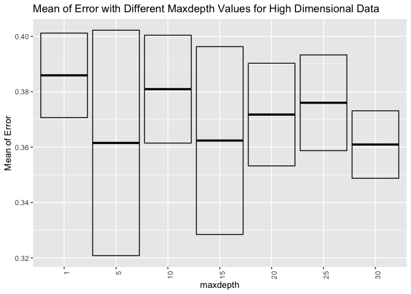

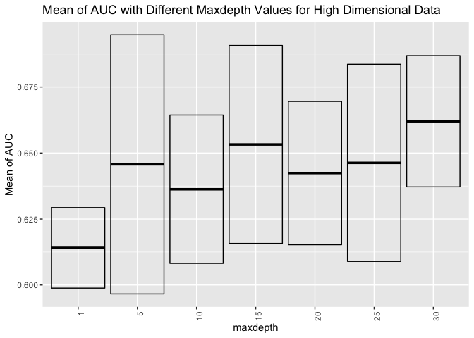

```r
best_maxdepth_high <- cv_results_trees_high$maxdepth[cv_results_trees_high$mean_AUC ==
                                           max(cv_results_trees_high$mean_AUC)]

best_maxdepth_high
```

```
## [1] 30
```

#### Low Dimensional Data

Based on the plots and table below, we find that the model with the highest mean AUC value has a “maxdepth” value of $20$.

```r
# create data frame to organize results
res_cv_trees_low <- as.data.frame(res_cv_trees_low)
colnames(res_cv_trees_low) <- c("mean_error", "sd_error", "mean_AUC", "sd_AUC")
cv_results_trees_low = data.frame(hyper_grid_trees, res_cv_trees_low)

# look at top 5 models with lowest AUC
cv_results_trees_low[order(cv_results_trees_low$mean_AUC, decreasing = TRUE), ][1:5, ]
```

```
##   maxdepth mean_error   sd_error  mean_AUC     sd_AUC
## 5       20  0.3841200 0.05899462 0.6357454 0.03894949
## 3       10  0.4078955 0.06381304 0.6246288 0.09375529
## 2        5  0.4078461 0.03543237 0.6135589 0.03927286
## 6       25  0.4046125 0.03058485 0.6022665 0.04414551
## 7       30  0.4162237 0.02341654 0.5902807 0.01572384
```

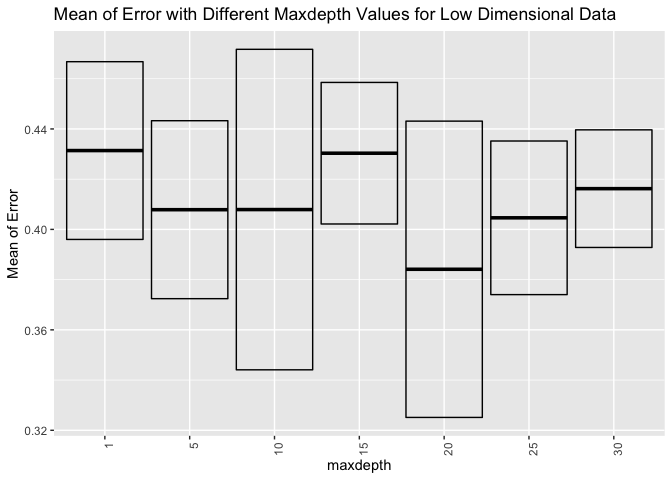

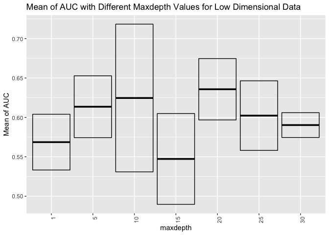

```r
best_maxdepth_low <- cv_results_trees_low$maxdepth[cv_results_trees_low$mean_AUC ==
                                           max(cv_results_trees_low$mean_AUC)]
best_maxdepth_low
```

```
## [1] 20
```

## Propensity Score Estimation

```r
# imbalanced dataset requires weights
# to be used in the trained model

weights_high <- rep(NA, length(df_high$A))
for (v in unique(df_high$A)){
  weights_high[df_high$A == v] = 0.5 * length(df_high$A) / length(df_high$A[df_high$A == v])
}


weights_low <- rep(NA, length(df_low$A))
for (v in unique(df_low$A)){
  weights_low[df_low$A == v] = 0.5 * length(df_low$A) / length(df_low$A[df_low$A == v])
}
```

#### High Dimensional Data

```r
start.time_propensity_score_high <- Sys.time()

# create tree model for high dimensional data with best cp parameter
tree_high <- rpart(A ~ . - Y, method = "class", data = df_high, maxdepth = best_maxdepth_high)

# calculate propensity scores
prop_score_high <- predict(tree_high, newdata = df_high[, -2], type = "prob")[, 2]

end.time_propensity_score_high <- Sys.time()
time_propensity_score_high <- end.time_propensity_score_high - start.time_propensity_score_high
time_propensity_score_high
```

```
## Time difference of 1.032289 secs
```

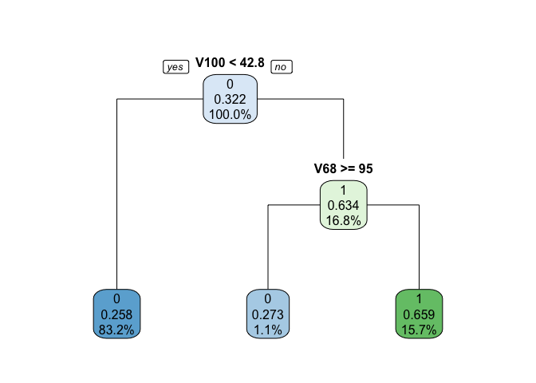

#### Low Dimensional Data

```r
start.time_propensity_score_low <- Sys.time()

# create tree model for low dimensional data with best cp parameter
tree_low <- rpart(A ~ . - Y, method = "class", data = df_low, maxdepth = best_maxdepth_low)

# calculate propensity scores
prop_score_low <- predict(tree_low, newdata = df_low[, -2], type = "prob")[, 2]

end.time_propensity_score_low <- Sys.time()
time_propensity_score_low <- end.time_propensity_score_low - start.time_propensity_score_low
time_propensity_score_low
```

```
## Time difference of 0.03410983 secs
```

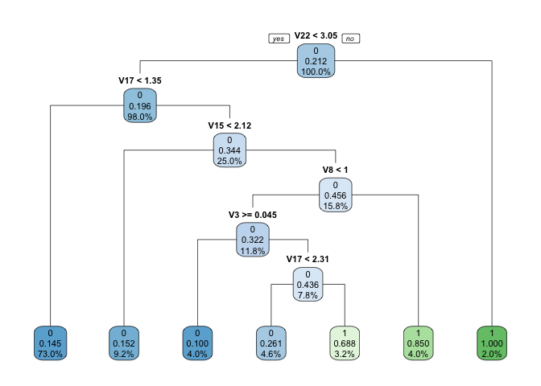

## ATE Estimation

With the estimated propensity scores on hand, we propose, explain, and discuss the pros and cons of three different ATE estimation algorithms: propensity matching, stratificationand weighted regression.

### Propensity Matching using Propensity Score from Regression Trees (Full Matching)

Full matching creates a series of matched sets, where each matched set contains at least one treated individual and at least one control individual (and each matched set may have many from either group). Full matching forms these matched sets in an optimal way, such that treated individuals who have many comparison individuals who are similar (on the basis of the propensity score) will be grouped with many comparison individuals, whereas treated individuals with few similar comparison individuals will be grouped with relatively fewer comparison individuals.(See Stuart (2010))

Our group is assigned the task of using propensity score for Full Matching. The distance of Propensity Score is defined as:
$$D_{ij}=\mid e_{i}-e_{j} \mid$$
where $e_{k}$ is the propensity score for individual $k$.

After the matched sets are obtained, calculate a “subclass effects” for each matched set/subclass, and then estimate overall ATE by an weighted average of the subclass effects where weights would be the number of individuals in each subclass.

#### Getting the Data Loaded for High and Low Dimension Data

```r
source("../lib/propensity_matching.R")

# match.data creates a dataset with one row per unit. It will be identical to the dataset supplied except
# that several new columns will be added containing information related to the matching

# Timing the process -- start
start.time_propensity_matching_low <- Sys.time()
match_Low_Dim <- get_match_obj(read.csv(lowDim_csv))
```

```
## Full matching...
## Calculating matching weights... Done.
```

```r
g.matches_low <- match.data(match_Low_Dim, data = read.csv(lowDim_csv), distance = "prop_score")

# Timing the process -- ends
end.time_propensity_matching_low <- Sys.time()
time_propensity_matching_low <- end.time_propensity_matching_low - start.time_propensity_matching_low
time_propensity_matching_low
```

```
## Time difference of 0.2356231 secs
```

```r
# Timing the process -- start
start.time_propensity_matching_high <- Sys.time()
match_High_Dim <- get_match_obj(read.csv(highDim_csv))
```

```
## Full matching...
## Calculating matching weights... Done.
```

```r
g.matches_high <- match.data(match_High_Dim, data = read.csv(highDim_csv), distance = "prop_score")

# Timing the process -- ends
end.time_propensity_matching_high <- Sys.time()
time_propensity_matching_high <- end.time_propensity_matching_high - start.time_propensity_matching_high
time_propensity_matching_high
```

```
## Time difference of 4.101987 secs
```

#### Estimating Effects After Matching

We diagnose the quality of the resulting matched samples. We would would like the treatment to be unrelated to the covariates such that:
$$\tilde{p}(X|T=1)=\tilde{p}(X|T=0)$$
where $\tilde{p}$ denotes the empirical distribution.

A plot of the standardized differences of means, gives us a quick overview of whether balance has improved for individual covariates.

#### Standardized Differences of Means After Matching Low Dimensional Data

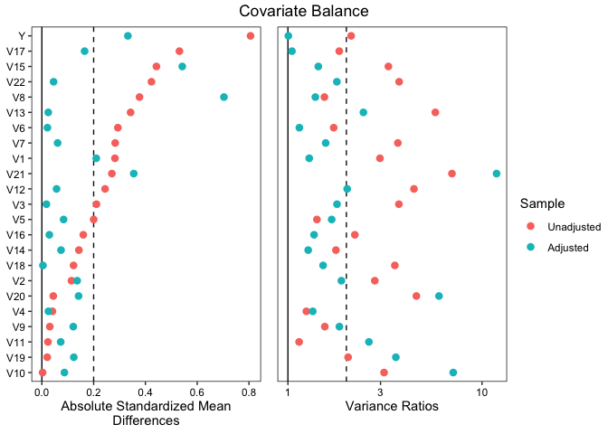

```r
love.plot(match_Low_Dim,stats = c("mean.diffs", "variance.ratios"), binary = "std",drop.distance = TRUE,
          var.order = "unadjusted",
          abs = TRUE,
          thresholds = c(m = .2, v = 2))
```

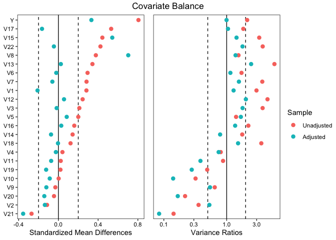

```r
love.plot(match_Low_Dim,stats = c("mean.diffs", "variance.ratios"), binary = "std",drop.distance = TRUE,
          var.order = "unadjusted",
          abs = FALSE,
          thresholds = c(m = .2, v = 2))
```

#### Standardized Differences of Means After Matching High Dimensional Data

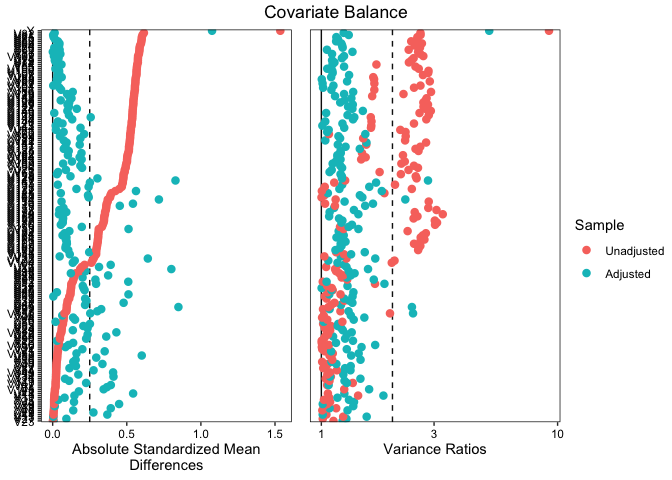

```r
love.plot(match_High_Dim,stats = c("mean.diffs", "variance.ratios"), binary = "std",drop.distance = TRUE,
          var.order = "unadjusted",
          abs = TRUE,
          thresholds = c(m = .25, v = 2))
```

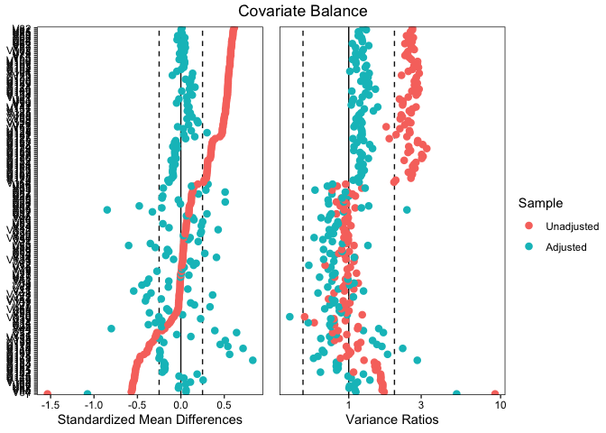

```r
love.plot(match_High_Dim,stats = c("mean.diffs", "variance.ratios"), binary = "std",drop.distance = TRUE,
          var.order = "unadjusted",
          abs = FALSE,
          thresholds = c(m = .25, v = 2))
```

For continuous covariates, we can also examine quantile–quantile (QQ) plots, which compare the empirical distributions of each variable. QQ plots compare the quantiles of a variable in the treatment group against the corresponding quantiles in the control group. If the two groups have identical empirical distributions, all points would lie on the 45 degree line.

#### eQQ Low Dimensional Data

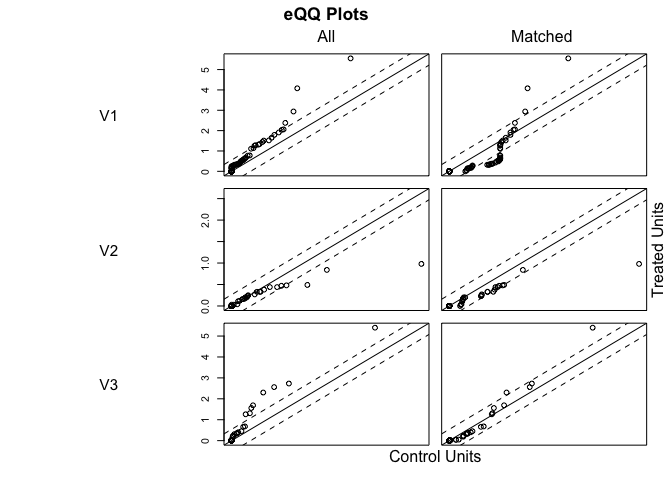

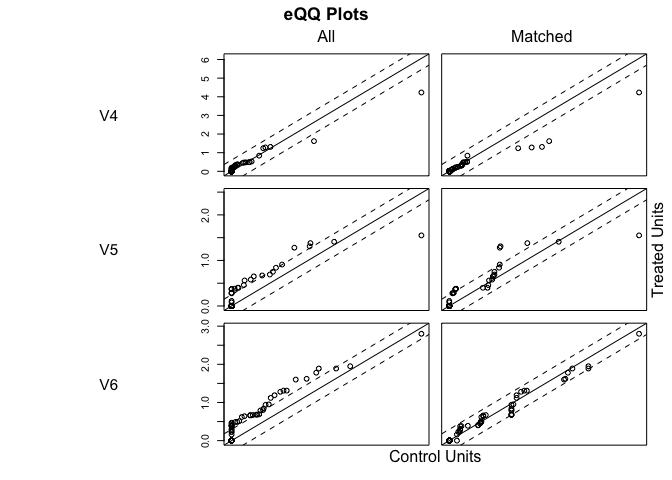

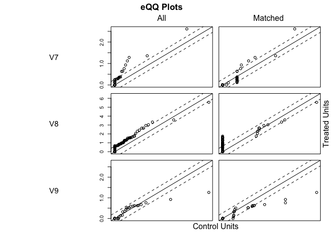

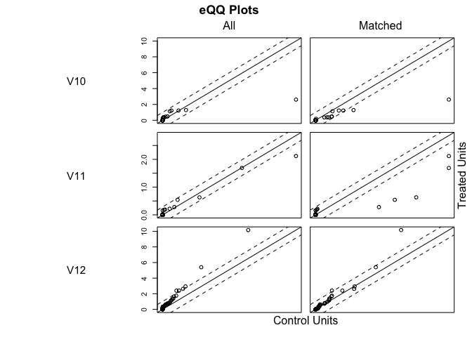

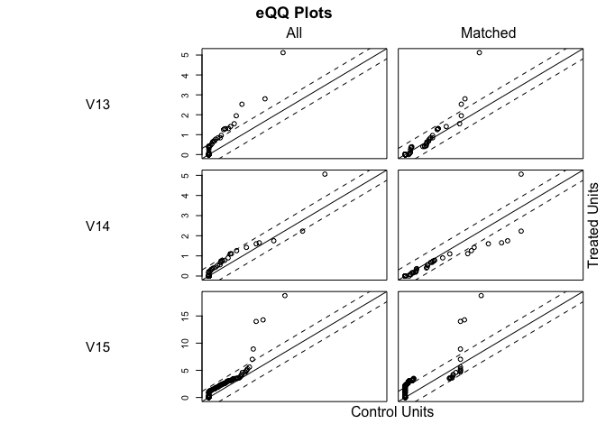

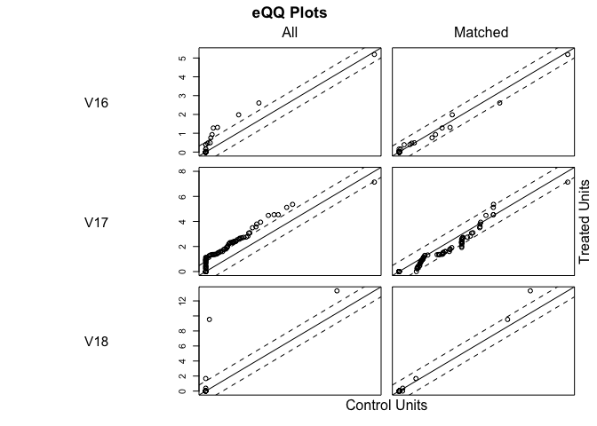

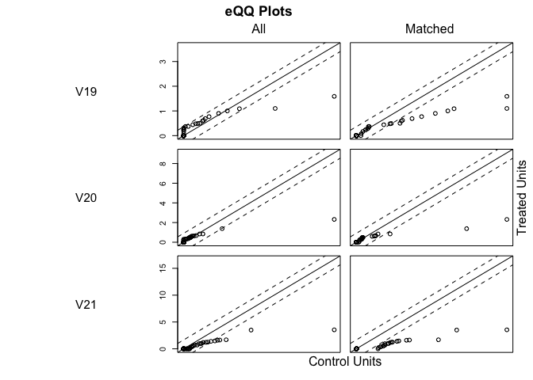

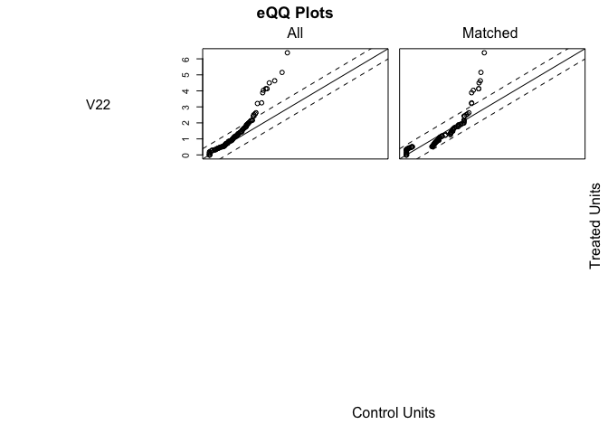

```r
#eQQ plot
plot(match_Low_Dim, type = "qq", interactive = FALSE)
```

#### eQQ High Dimensional Data

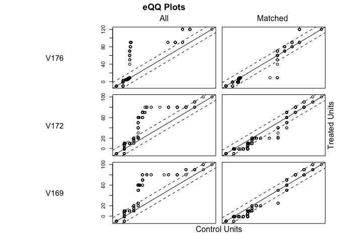

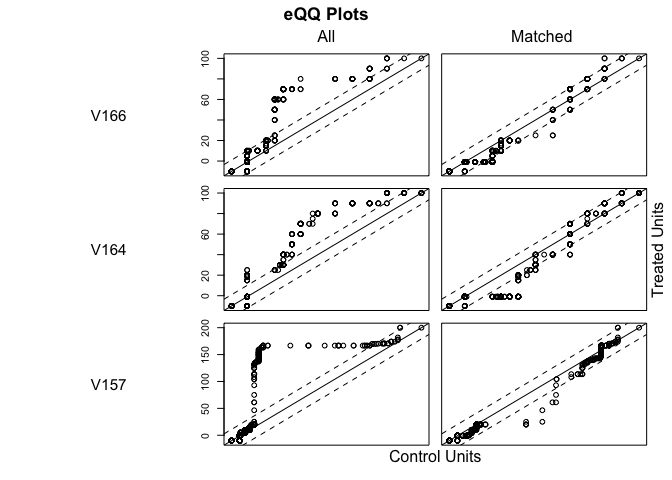

```r
#eQQ plot
plot(match_High_Dim, type = "qq", interactive = FALSE, which.xs = c("V176","V172", "V169", "V166", "V164", "V157"))
```

The y-axis displays the value of the covariate for the treated units, and the x-axis displays the the value of the covariate at the corresponding quantile in the control group. When values fall on the 45 degree line, the groups are balanced. We can see that some covariates remain somewhat imbalanced, but other covariates have much better balance after matching than before.

Statistics related to the difference in the empirical cumulative density functions (eCDFs) of each covariate between groups allow assessment of imbalance across the entire covariate distribution of that covariate rather than just its mean or variance.

#### eCDFs Low Dimensional Data

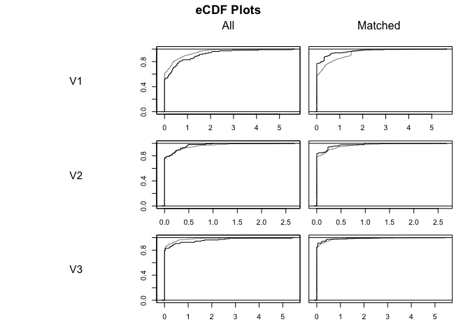

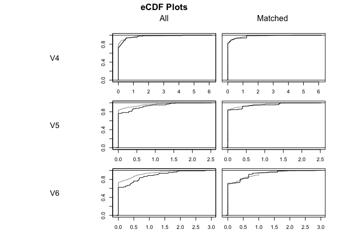

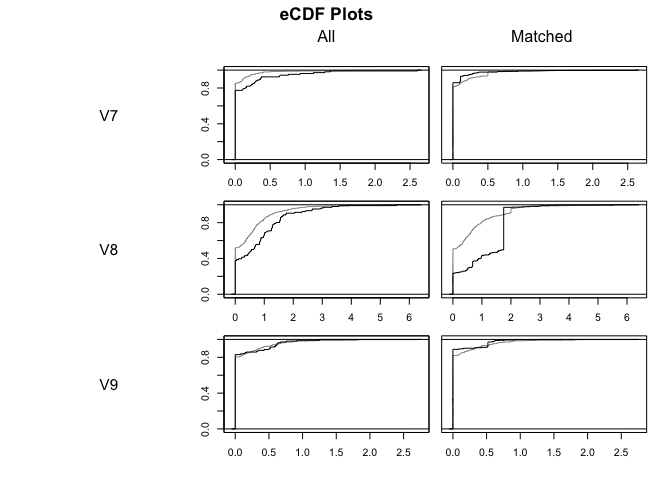

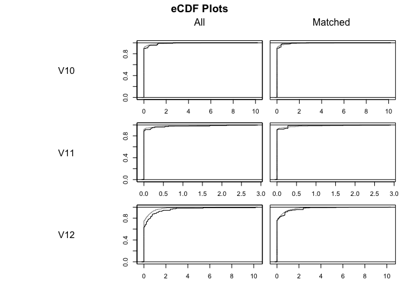

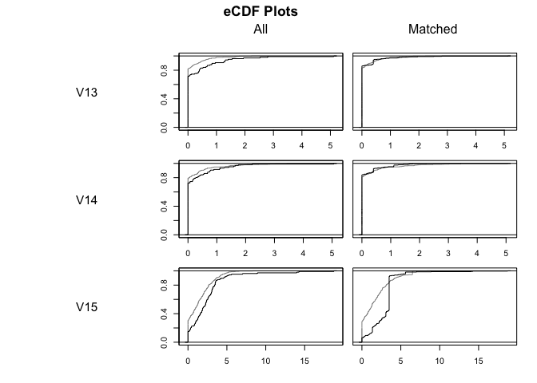

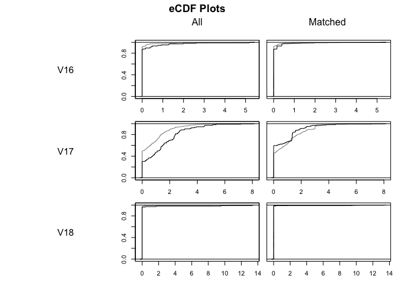

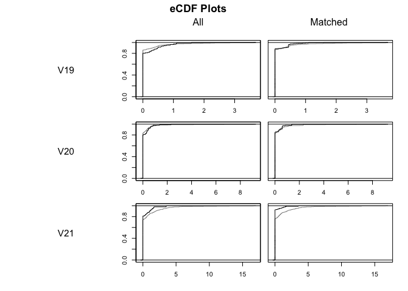

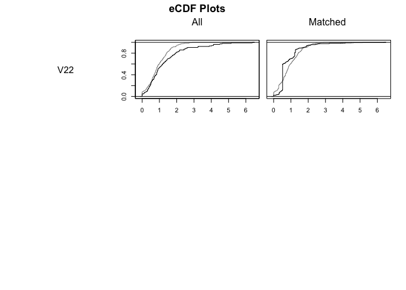

```r
plot(match_Low_Dim, type = "ecdf", interactive = FALSE)
```

#### eCDFs High Dimensional Data

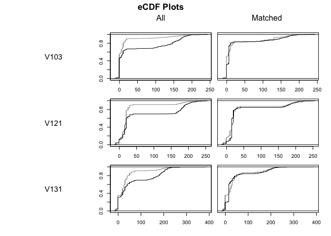

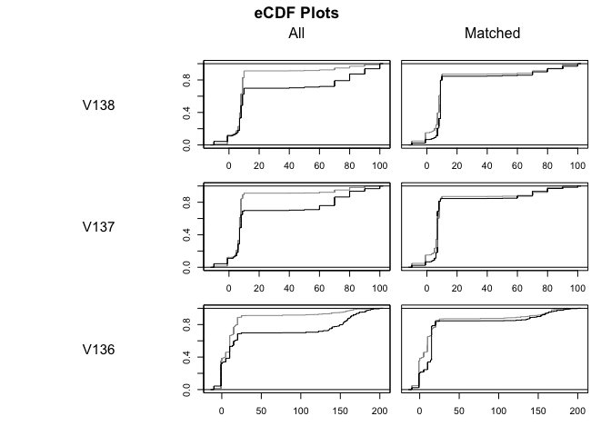

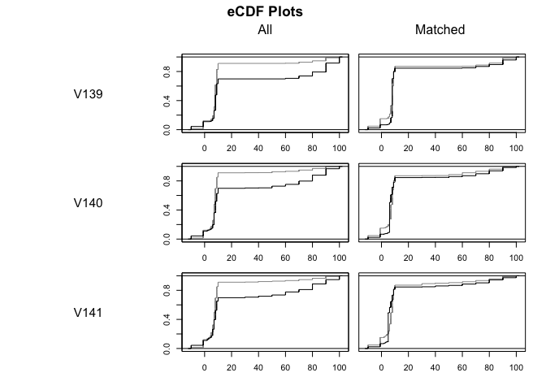

```r
plot(match_High_Dim, type = "ecdf", interactive = FALSE, which.xs = c("V103","V121","V131","V138","V137","V136","V139", "V140", "V141", "V141"))
```

The x-axis display the covariate values and the y-axis display the proportion of the sample at or less than that covariate value. Perfectly overlapping lines indicate good balance. The black line corresponds to the treated group and the gray line to the control group.

We see adequate overlap of the propensity scores, with a good control match for each treated individual. For weighting or subclassification, plots such as the ones below show the dots with their size proportional to their weight.

#### Distribution of Propensity Scores High Dimensional Data

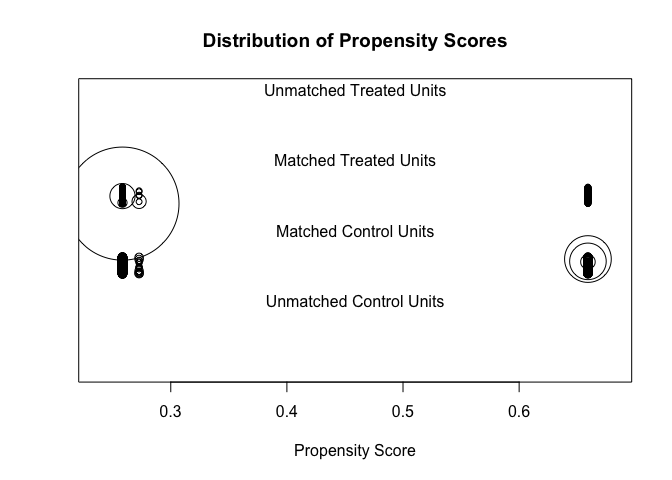

```r
plot(match_High_Dim, type = "jitter", interactive = FALSE)
```

#### Distribution of Propensity Scores Low Dimensional Data

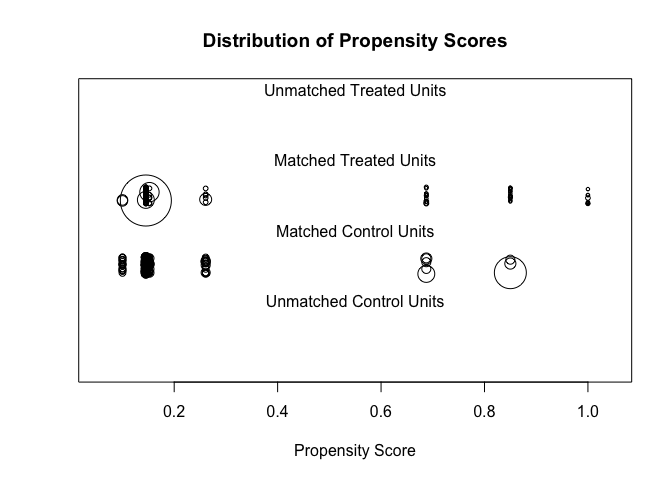

```r
plot(match_Low_Dim, type = "jitter", interactive = FALSE)
```

#### Calculating the ATE after Full matching

Including interactions between the treatment and covariates can be beneficial when effect modification by the covariates may be present. In order to interpret the coefficient on treatment as a marginal effect estimate, we need to center the covariates at their means in the target population. Below we use the strategy of centering the covariates at their means.

```r
md_cen <- g.matches_high
ATE_fullmatching_high_fit <- get_ATE_using_treatment_covariate_interactions(g.matches_high,185)

#Only output the intercept and coefficient on treatment
result_ATE_high<-coeftest(ATE_fullmatching_high_fit, vcov. = vcovCL, cluster = ~subclass)[1:2,]


ATE_fullmatching_high <- result_ATE_high[2][1]
ATE_fullmatching_high
```

```
## [1] -57.49297
```

```r
md_cen <- g.matches_low
ATE_fullmatching_low_fit <- get_ATE_using_treatment_covariate_interactions(g.matches_low,22)

#Only output the intercept and coefficient on treatment
result_ATE_low<-coeftest(ATE_fullmatching_low_fit, vcov. = vcovCL, cluster = ~subclass)[1:2,]

ATE_fullmatching_low <- result_ATE_low[2][1]
ATE_fullmatching_low
```

```
## [1] 2.073773
```

### Stratification

In the stratification method, we aim at dividing the data set into strata such that the propensity scores in each stratum are close enough. For choosing number of strata, $K$, five ($5$) was advocated by Rosenbaum and Rubin (1984). However, the propensity scores generated by CART are discrete numbers that are not proportional to the quantiles. If we divide the data into five strata by quantiles, each having roughly 20% of the total number of objects, the propensity scores in each stratum might not be similar.

Therefore, we divided the low dimensional data set into 6 stratum, and the high dimensional data set into 2 stratum, where propensity score in each strata is either uniform or significantly close.

The following formula was used to calculate the ATE:

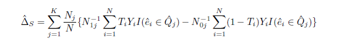

where $K$ is the number of strata, $\hat{e}$ is the estimated propensity score, $Y$ is the response for each observation, and $T$ is the treatment variable (either $0$ or $1$). $N_j$ is the number of individuals in stratum $j$. $N_{1j}$ is the number of “treated” individuals in stratum $j$, while $N_{0j}$ is the number of “controlled” individuals in stratum $j$. $\hat{Q_j} = (\hat{q_{j-1}}, \hat{q_j}]$ where $\hat{q_j}$ is the $j$th sample quantile of the estimated propensity scores.

#### Low Dimensional Data

```r
# Timing the process -- start
start.time_stratification_low <- Sys.time()

prop_score <- prop_score_low
df_strat_low <- cbind(df_low, prop_score)
df_strat_low <- df_strat_low[,c("Y","A","prop_score")]

strata_low_1 <- df_strat_low[df_strat_low$prop_score <= 0.125, ]
sum_strata_low_1 <- strata_low_1 %>%
  group_by(A) %>%
  summarise(Avg_Y = mean(Y))

strata_low_2 <- df_strat_low[0.125 < df_strat_low$prop_score & df_strat_low$prop_score <= 0.250, ]
sum_strata_low_2 <- strata_low_2 %>%
  group_by(A) %>%
  summarise(Avg_Y = mean(Y))

strata_low_3 <- df_strat_low[0.250 < df_strat_low$prop_score & df_strat_low$prop_score <= 0.5, ]
sum_strata_low_3 <- strata_low_3 %>%
  group_by(A) %>%
  summarise(Avg_Y = mean(Y))

strata_low_4 <- df_strat_low[0.5 < df_strat_low$prop_score & df_strat_low$prop_score <= 0.75, ]
sum_strata_low_4 <- strata_low_4 %>%
  group_by(A) %>%
  summarise(Avg_Y = mean(Y))

strata_low_5 <- df_strat_low[0.75 < df_strat_low$prop_score & df_strat_low$prop_score <= 0.875, ]
sum_strata_low_5 <- strata_low_5 %>%
  group_by(A) %>%
  summarise(Avg_Y = mean(Y))

strata_low_6 <- df_strat_low[0.875 < df_strat_low$prop_score, ]
sum_strata_low_6 <- strata_low_6 %>%
  group_by(A) %>%
  summarise(Avg_Y = mean(Y))

ATE_Stratification_low <- as.double(((sum_strata_low_1[2,2] - sum_strata_low_1[1,2])*nrow(strata_low_1) + (sum_strata_low_2[2,2] - sum_strata_low_2[1,2])*nrow(strata_low_2) +
(sum_strata_low_3[2,2] - sum_strata_low_3[1,2])*nrow(strata_low_3) +
(sum_strata_low_4[2,2] - sum_strata_low_4[1,2])*nrow(strata_low_4) +
(sum_strata_low_5[2,2] - sum_strata_low_5[1,2])*nrow(strata_low_5) +
(sum_strata_low_6[1,2])*nrow(strata_low_6))/nrow(df_strat_low))
ATE_Stratification_low
```

```
## [1] 4.388841
```

```r
# Timing the process -- ends
end.time_stratification_low <- Sys.time()
time_stratification_low <- end.time_stratification_low - start.time_stratification_low
time_stratification_low
```

```
## Time difference of 0.07218885 secs
```

The ATE of low dimensional data calculated by stratification is 4.388841.

#### High Dimensional Data

```r
# Timing the process -- start
start.time_stratification_high <- Sys.time()

prop_score <- prop_score_high
df_strat_high <- cbind(df_high, prop_score)
df_strat_high <- df_strat_high[,c("Y","A","prop_score")]

strata_high_1 <- df_strat_high[df_strat_high$prop_score <= 0.3, ]
sum_strata_high_1 <- strata_high_1 %>%
  group_by(A) %>%
  summarise(Avg_Y = mean(Y))

strata_high_2 <- df_strat_high[0.3 < df_strat_high$prop_score, ]
sum_strata_high_2 <- strata_high_2 %>%
  group_by(A) %>%
  summarise(Avg_Y = mean(Y))

ATE_Stratification_high <- as.double(((sum_strata_high_1[2,2] - sum_strata_high_1[1,2])*nrow(strata_high_1) + (sum_strata_high_2[2,2] - sum_strata_high_2[1,2])*nrow(strata_high_2)) /nrow(df_high))
ATE_Stratification_high
```

```
## [1] -61.93289
```

```r
# Timing the process -- ends
end.time_stratification_high <- Sys.time()
time_stratification_high <- end.time_stratification_high - start.time_stratification_high
time_stratification_high
```

```
## Time difference of 0.02580905 secs
```

### Weighted Regression

Weighted least square estimation of the regression function:
$$Y_{i} = \alpha_{0}+\tau*T_{i}+\alpha_{1}^{'}*Z_{i}+\alpha_{2}^{'}*(Z_{i}-\bar{Z})*T_{i}+\varepsilon _{i}$$

The weights are the same as the ones of “Inverse Propensity Weighting”. The $Z_{i}$ are a subset of the covariates $X_{i}$; with sample average $\bar{Z}$. $\tau$ is an estimate for ATE. For the method of selecting Z, we get the estimation using linear regressions:
$$Y_{i}=\beta_{k0}+\beta_{k1}*T_{i}+\beta_{k2}*X_{ik}+\varepsilon_{i}$$
We calculate the t-statistic for the test of the null hypothesis that the slope coefficient $\beta_{k2}$ is equal to zero in each of these regressions, and now select for $Z$ all the covariates with a t-statistic larger in absolute value than $t_{reg}$. Thus, we include in the final regression all covariates which have substantial correlation with the outcome conditional on the treatment. (See Hirano and Imbens (2001))

#### Loading the Data and Data Preprocessing

#### Finding weights and regression

```r
# timing starts
start.time_weighted_regression_low <- Sys.time()
start.time_weighted_regression_high <- Sys.time()


#The weight will be used for the weighted least square estimation of the regression function. (formula 1)
# prop_score_low<-g.matches_low$prop_score
# prop_score_high<-g.matches_high$prop_score

weight_low <- cbind(as.numeric(A_low), prop_score_low) %>%
  as_tibble %>%
  mutate(weights = (V1/prop_score_low + (1-V1)/(1-prop_score_low)))
weight_low = weight_low[,"weights"]
weight_high <- cbind(as.numeric(A_high), prop_score_low) %>%
  as_tibble %>%
  mutate(weights = (V1/prop_score_high + (1-V1)/(1-prop_score_high)))
weight_high = weight_high[,"weights"]

#### Linear regression for selecting covarites
#Calculate the t-statistic
#we select for Z all the covariates with t-statsitic larger in absolute value than t reg (formula 2)

filter_low <- summary(lm(Y~., data = df_low))$coef[,4][3:24]<0.05
Z_low <- cbind(A_low, X_low[,filter_low])

filter_high <- summary(lm(Y~., data = df_high))$coef[,4][3:ncol(X_high)]<0.05
Z_high <- cbind(A_high, X_high[,filter_high])

#### Modify the data
Z_low <- Z_low %>% apply(2, as.numeric)
Z_high <- Z_high %>% apply(2, as.numeric)

#### Final Regression for ATE
Y_low <- df_low$Y
Y_high <- df_high$Y


#fit the weighted regression model and pick the coefficient of the treatment since ATE is the coeff of the treatment Ti (formula 1)
#  lowdim
weighted_low <- lm(Y_low ~ Z_low, weights = as.numeric(unlist(weight_low)))
ATE_weightedreg_low <- coef(weighted_low)[2]


# timing ends
end.time_weighted_regression_low <- Sys.time()
time_weighted_regression_low <- end.time_weighted_regression_low - start.time_weighted_regression_low
time_weighted_regression_low
```

```
## Time difference of 0.216265 secs
```

```r
#  highdim
weighted_high <- lm(Y_high ~ Z_high, weights = as.numeric(unlist(weight_high)))
ATE_weightedreg_high <- coef(weighted_high)[2]

# timing ends
end.time_weighted_regression_high <- Sys.time()
time_weighted_regression_high <- end.time_weighted_regression_high - start.time_weighted_regression_high
time_weighted_regression_high
```

```
## Time difference of 0.2285371 secs
```

#### Summarizing Final Results

```r
ATE_weightedreg_low
```

```
##    Z_low
## 2.306471
```

```r
ATE_weightedreg_high
```

```
##   Z_high
## -57.1627
```

## Results

We compare the accuracy and performance of the three ATE Estimation procedures below.

### ATE Results

We are provided the true ATE values of $-54.8558$ for the high dimensional data and $2.0901$ for the low dimensional data.

```
##                     High Dimensional Data Low Dimensional Data
## True                           -54.855800             2.090100
## Stratification                 -61.932886             4.388841
## Propensity Matching            -57.492971             2.073773
## Weighted Regression            -57.162697             2.306471
```

From the table above, we see that weighted regression performed the best for the high dimensional data and propensity matching performed the best for the low dimensional data.

### Run Time Results

```
##                             High Dimensional Data Low Dimensional Data
## Propensity Score Estimation            1.03228903           0.03410983
## Stratification                         0.02580905           0.07218885
## Propensity Matching                    4.10198712           0.23562312
## Weighted Regression                    0.22853708           0.21626496
```

Given the nature of trees, propensity score estimations are quickly calculated once we have the proper hyperparameters selected from cross-validation–even for the high dimensional data, propensity score estimations did not take more than two seconds.

Given the size of the two datasets, the stratification is the fastest method. However, descriptions of run times are device dependant and we are making conclusions based on average run times we saw through numerous iterations.

## Conclusion

Overall, we believe that using classification/regression trees for propensity scores was not the ideal approach for either dataset. While we cross-validated the hyperparameter of maxdepth, to help avoid with overfitting, the mean error of choosing different parameters didn’t vary much, which means that the tree model yields similar propensity score estimation regardless of the model complexity.

The results were relatively consistent among all three methods. The propensity matching and weighted regression are getting quite satisfactory results. But the stratification’s estimation is more deviated from the true values. Specifically, the weighted regression yields the best ATE estimation for the high dimensional dataset, while the propensity matching yields the best ATE estimation for the low dimensional dataset. While we might not completely trust the estimation of these methods, they show a fast and easy way to get a general sense of the average treatment effect.

## References

- Atkinson, Beth. “Recursive Partitioning And Regression Trees.” R Documentation, DataCamp, www.rdocumentation.org/packages/rpart/versions/4.1-15/topics/rpart.
- Austin, Peter C. 2011. “An Introduction to Propensity Score Methods for Reducing the Effects of Confounding in Observational Studies.” Multivariate Behavioral Research 46 (3): 399–424.
- Hastie, Trevor,, Robert Tibshirani, and J. H Friedman. The Elements of Statistical Learning: Data Mining, Inference, and Prediction. 2nd ed. New York: Springer, 2009. Print.
- Lunceford, Jared K, and Marie Davidian. 2004. “Stratification and Weighting via the Propensity Score in Estimation of Causal Treatment Effects a Comparative Study.” Statistics in Medicine 23 (19): 2937–60.
- Rosenbaum PR, Rubin DB. The central role of the propensity score in observational studies for causal efiects.Biometrika 1983; 70:41–55.
- Stuart E. A. (2010). Matching methods for causal inference: A review and a look forward. Statistical science : a review journal of the Institute of Mathematical Statistics, 25(1), 1–21. https://doi.org/10.1214/09-STS313